# Accenture_4

## 1.Load Data

```python
#Load Data
import pandas as pd

# Load data
product_inventory_df = pd.read_csv('https://storage.googleapis.com/datalynn-datasets/interview-challenge/logistics-and-supply-chain/Accenture_4/product_inventory.csv')
sales_records_df = pd.read_csv('https://storage.googleapis.com/datalynn-datasets/interview-challenge/logistics-and-supply-chain/Accenture_4/sales_records.csv')
```

## 3. Questions for the Data Challenge##

### 3.1 Basic SQL Knowledge

Write an SQL query to find the 'Product_Category' that had the most sales ('Quantity_Sold') in each 'Sales_Region'. Also include the total sales price for that category in each region.

```python
# Step 1: Install SQLite3
!apt-get -qq install sqlite3

# Step 2: Verify the installation
!sqlite3 --version
```

[output not shown]

#### **Answer 3.1**

```python
import json

product_inventory_df['Seasonality'] = product_inventory_df['Seasonality'].apply(json.dumps)

# The rest of your code...

import sqlite3
# read your data into pandas DataFrames
# connect to your sqlite database
conn = sqlite3.connect('database_name.db')

# Convert your Pandas dataframes to SQL tables
product_inventory_df.to_sql('product_inventory_df', conn, if_exists='replace', index=False)
sales_records_df.to_sql('sales_records_df', conn, if_exists='replace', index=False)

query3 = '''
  WITH sales_totals AS (
      SELECT
          sr.Sales_Region,
          pi.Product_Category,
          SUM(sr.Quantity_Sold) as Total_Quantity_Sold,
          SUM(sr.Quantity_Sold * sr.Sales_Price) as Total_Sales_Price
      FROM
          sales_records_df sr
      JOIN
          product_inventory_df pi
      ON
          sr.Product_ID = pi.Product_ID
      GROUP BY
          sr.Sales_Region,
          pi.Product_Category
  ),

  ranked_sales AS (
      SELECT
          Sales_Region,
          Product_Category,
          Total_Quantity_Sold,
          Total_Sales_Price,
          RANK() OVER (PARTITION BY Sales_Region ORDER BY Total_Quantity_Sold DESC) as rank
      FROM
          sales_totals
  )

  SELECT
      Sales_Region,
      Product_Category,
      Total_Quantity_Sold,
      Total_Sales_Price
  FROM
      ranked_sales
  WHERE
      rank = 1;
'''

Most_Sale_df = pd.read_sql_query(query3, conn)
# close the connection
conn.close()
Most_Sale_df
```

|  | Sales_Region | Product_Category | Total_Quantity_Sold | Total_Sales_Price |
| --- | --- | --- | --- | --- |
| 0 | East | Furniture | 1672374 | 5.906430e+09 |
| 1 | North | Furniture | 1663723 | 5.931265e+09 |
| 2 | South | Furniture | 1630840 | 5.767543e+09 |
| 3 | West | Furniture | 1622913 | 5.887891e+09 |

## 3.2 Cost-Based Risk Metric - Validation (Python/SQL)

Assume that a stockout event's cost is proportional to the Product_Cost but inversely proportional to the Lead_Time (more lead time means a lesser impact as we have more time to react). At the same time, the cost of holding excess inventory is a function of Product_Cost and Current_Stock_Level. Given these conditions, define a cost-based risk metric that balances both stockouts and overstock situations. How would you validate this metric using historical data?

#### **Answer 3.2**

```python
import sqlite3
import pandas as pd

# connect to your sqlite database
conn = sqlite3.connect('database_name.db')

# Convert your Pandas dataframes to SQL tables
product_inventory_df.to_sql('product_inventory_df', conn, if_exists='replace', index=False)
sales_records_df.to_sql('sales_records_df', conn, if_exists='replace', index=False)

# read your data into pandas DataFrames
query1 = 'SELECT * FROM product_inventory_df'
query2 = 'SELECT * FROM sales_records_df'
product_inventory_df = pd.read_sql_query(query1, conn)
sales_records_df = pd.read_sql_query(query2, conn)

# close the connection
conn.close()

# merge the two dataframes on 'Product_ID'
df = pd.merge(product_inventory_df, sales_records_df, on='Product_ID')

# calculate stockout cost
df['stockout_cost'] = df['Product_Cost'] / df['Lead_Time']

# calculate overstock cost
overstock_cost_proportion = 0.1  # parameter that you may need to adjust
df['overstock_cost'] = overstock_cost_proportion * df['Product_Cost'] * df['Current_Stock_Level']

# define your risk metric
weight_stockout = 0.6
weight_overstock = 0.4
df['risk_metric'] = weight_stockout * df['stockout_cost'] + weight_overstock * df['overstock_cost']
```

## 3.3 Time to Stockout Forecasting - Time Series Analysis (Python)

Given the historical sales data and current stock levels, design a method to forecast the time to stockout for each product using a time series analysis approach. How would you account for both macro trends and seasonality in sales in your model? Furthermore, given the uncertainty in future sales, how would you calculate a confidence interval for your time to stockout forecast?

#### **Answer 3.3**

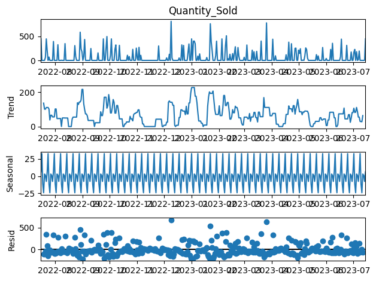

```
Estimated time to stockout for product 6863: 8.458748197437645 days
```

```python
import pandas as pd
from statsmodels.tsa.statespace.sarimax import SARIMAX
from statsmodels.tsa.seasonal import seasonal_decompose
import matplotlib.pyplot as plt

# Choose one product
product_id = sales_records_df['Product_ID'].iloc[0]

# Get historical sales data for this product
product_sales_df = sales_records_df[sales_records_df['Product_ID'] == product_id].copy()

# Make sure the data is sorted by date
product_sales_df = product_sales_df.sort_values('Date_of_Sale')

# Convert 'Date_of_Sale' column to datetime format
product_sales_df['Date_of_Sale'] = pd.to_datetime(product_sales_df['Date_of_Sale'])

# Set 'Date_of_Sale' as the index to be able to apply time series analysis
product_sales_df.set_index('Date_of_Sale', inplace=True)

# Let's say we are interested in daily sales, so we will resample the data to get daily total sales quantity
daily_sales = product_sales_df['Quantity_Sold'].resample('D').sum()

# We can decompose the time series to observe the trend and seasonality
decomposed = seasonal_decompose(daily_sales)

# plot trend, seasonality, and residuals
decomposed.plot()
plt.show()

# Fit a SARIMA model
model = SARIMAX(daily_sales, order=(1, 1, 1), seasonal_order=(1, 1, 1, 12))
results = model.fit(disp=-1)

# Predict sales for the next 30 days
forecast = results.predict(start=len(daily_sales), end=len(daily_sales) + 30)

# Get the current stock level
current_stock_level = product_inventory_df.loc[product_inventory_df['Product_ID'] == product_id, 'Current_Stock_Level']

if len(current_stock_level) > 0:
    current_stock_level = current_stock_level.values[0]
    # Estimate the time to stockout
    time_to_stockout = current_stock_level / forecast.iloc[0]
    print(f'Estimated time to stockout for product {product_id}: {time_to_stockout} days')
else:
    print(f'Product {product_id} not found in inventory.')
```

## 3.4 Category-Wise Price Volatility - Feature Engineering (Python/SQL)

Besides capturing the trend and volatility of the Sales_Price, suppose you notice that certain Product_Categories are more prone to price changes than others. How would you create a feature that encapsulates this category-wise price volatility? What potential challenges do you foresee, and how could you validate this new feature's usefulness for your model?

#### **Answer 3.4**

```python
# Merge the sales and product inventory dataframes on 'Product_ID'
merged_df = pd.merge(sales_records_df, product_inventory_df, on='Product_ID', how='left')

# Calculate price volatility for each Product_Category
price_volatility = merged_df.groupby('Product_Category')['Sales_Price'].std().reset_index()
price_volatility.columns = ['Product_Category', 'Price_Volatility']

# Merge this feature back into the merged_df dataframe
merged_df = pd.merge(merged_df, price_volatility, on='Product_Category', how='left')

print(merged_df.head())
```

```
   Sales_ID  Product_ID  Quantity_Sold Date_of_Sale Sales_Region  Sales_Price  \
0     68649       52188             57   2022-09-23         West      2253.89
1     24228       37993            614   2023-03-22         West      3224.02
2      8329        2249            115   2022-08-12         West      1982.35
3     95025       48467             85   2023-05-15         West      1252.99
4     49628        7387             26   2023-04-13        South      1153.02

                                  Product_Name Product_Category  Product_Cost  \
0  Balanced motivating artificial intelligence         Clothing       1645.06
1               Business-focused 24/7 software            Books       1740.38
2           Ergonomic encompassing open system        Furniture       1251.23
3                Face-to-face radical alliance      Electronics        673.60
4        Reverse-engineered reciprocal project      Electronics        813.22

   Current_Stock_Level  Safety_Stock_Level  Lead_Time  Price_Volatility
0                  966                  58          2       2502.348796
1                  860                  17         23       2403.890390
2                  456                  44         27       2284.806203
3                  471                  55         18       2159.639770
4                   77                  94         10       2159.639770
```

## 3.5 Machine Learning-Based Model - Selection and Justification

Given the problem's probabilistic nature and the multiple features at hand (both categorical and continuous), discuss why traditional regression models may fall short. Propose a machine learning-based approach and discuss its benefits in this context. In your response, consider the interpretability of the model, the handling of non-linearities, and the ability to handle multiple feature interactions. Why would your chosen model be a better fit?

## 3.6 Hierarchical Model - Design and Optimization (Python)

Given that the data exhibits both temporal (time-series) and cross-sectional (across regions) variations, how would you design a hierarchical model to capture these dynamics? Discuss a strategy for optimizing such a model. How would you ensure that your model isn't overfitting to certain temporal or regional characteristics?

#### **Answer 3.6**

```python
import pandas as pd
from statsmodels.tsa.statespace.sarimax import SARIMAX
from sklearn.ensemble import RandomForestRegressor
from sklearn.model_selection import train_test_split
from sklearn.metrics import mean_squared_error

# For each region, we create a separate model
for region in sales_records_df['Sales_Region'].unique():
    region_df = sales_records_df[sales_records_df['Sales_Region'] == region]

    # For simplicity, we aggregate the sales data by date
    daily_sales = region_df.groupby('Date_of_Sale')['Quantity_Sold'].sum()

    # We split the data into a training set and a test set
    train_size = int(len(daily_sales) * 0.8)
    train, test = daily_sales[:train_size], daily_sales[train_size:]

    # We fit a SARIMA model to the training data
    model = SARIMAX(train, order=(1, 1, 1), seasonal_order=(1, 1, 1, 12))
    model_fit = model.fit(disp=False)

    # We use the model to forecast the sales in the test set
    predictions = model_fit.predict(start=len(train), end=len(train) + len(test) - 1)

    # We calculate the RMSE of the predictions
    rmse = mean_squared_error(test, predictions, squared=False)
    print(f'RMSE for region {region}: {rmse}')

    # Now let's use a Random Forest to model the cross-sectional variations
    # For simplicity, we only use the 'Product_Cost', 'Current_Stock_Level', 'Safety_Stock_Level', and 'Lead_Time' features
    X = product_inventory_df[['Product_Cost', 'Current_Stock_Level', 'Safety_Stock_Level', 'Lead_Time']]
    y = product_inventory_df['Current_Stock_Level']  # For simplicity, we use the current stock level as the target

    # We split the data into a training set and a test set
    X_train, X_test, y_train, y_test = train_test_split(X, y, test_size=0.2, random_state=42)

    # We fit a Random Forest to the training data
    rf = RandomForestRegressor(n_estimators=100, random_state=42)
    rf.fit(X_train, y_train)

    # We use the model to predict the stock levels in the test set
    predictions = rf.predict(X_test)

    # We calculate the RMSE of the predictions
    rmse = mean_squared_error(y_test, predictions, squared=False)
    print(f'RMSE for Random Forest: {rmse}')
```

```
RMSE for region West: 4788.5759477250385
RMSE for Random Forest: 1.041135197752913
```

```
RMSE for region North: 4295.707221398963
RMSE for Random Forest: 1.041135197752913
```

```
RMSE for region South: 3465.4690948738094
RMSE for Random Forest: 1.041135197752913
```

```
RMSE for region East: 3395.9638744917897
RMSE for Random Forest: 1.041135197752913
```

## 3.7 Model Performance - Interpretability and Business Recommendations

Assume you have built your model and found that its performance varies across product categories and sales regions. How would you leverage methods like SHAP (SHapley Additive exPlanations) or other model interpretability techniques to understand why this is the case? How could these insights be used to provide specific recommendations for different regions or product categories? Additionally, how might these insights inform your strategy for data collection or feature engineering in the future?

- Hint:SHAP (SHapley Additive exPlanations) is a game theory approach to explain the output of any machine learning model. It connects optimal credit allocation with local explanations using the classic Shapley values from cooperative game theory and their related extensions.